# ST 503 Hw 5

Robin Baldeo

November 12, 2018

### Question 1(Exercise 10.7 in LMR)

```r
set.seed(1)
funky<- function(x) sin(2*pi*x^3)^3
x<- seq(0,1, by=.01)
y<- funky(x) + .1*rnorm(101)
```

#### (A)

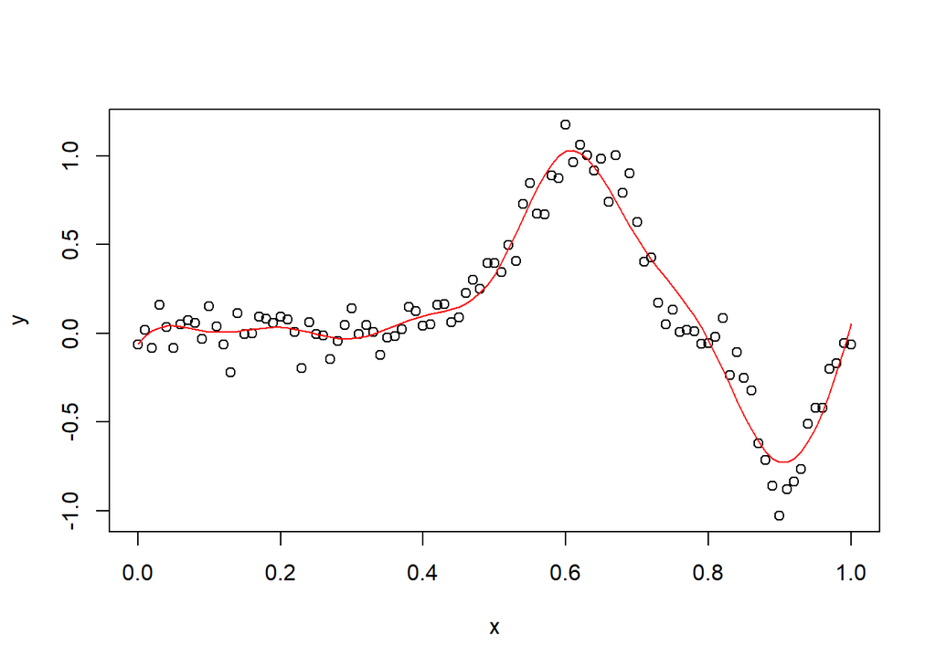

```r
plot(x, y)
mod12<- lm(y~bs(x,12))
pr<- predict(mod12,newdata = as.data.frame(x ))
lines(x, pr, col = "red")
```

#### (B)

```r
#using r built in AIC
AIC(mod12)
```

```
## [1] -118.4576
```

The AIC for the model with 12 knots is -118.4575744.

#### (C)

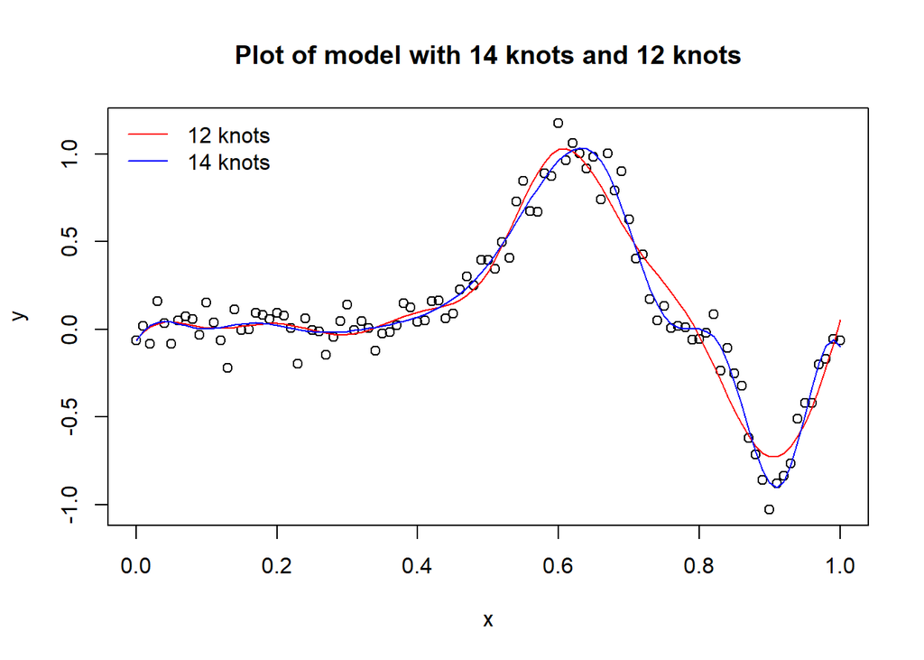

```r
plot(x, y, main= "Plot of model with 14 knots and 12 knots")
lines(x, pr, col = "red")

f<- function(p){
  mod<- lm(y~bs(x,p))
  return(AIC(mod))
}


aic_<- matrix(, nrow= length(3:20), ncol = 2)
best <- matrix(, nrow= 1, ncol = 2)

#extract model with the lowest AIC
for(i in seq(3:20)){
  j = i + 2;
  aic_[i, 1]= f(j);  aic_[i, 2]= j
  if(i == length(3:20)){
    for(v in 1:length(3:20)){
      if(aic_[v, 1] == min(aic_[, 1])){
        #sotring the lowest aic to use as best plot
        best[1,1] = aic_[v,1];  best[1,2] = aic_[v,2]
        aic_[v,1]
        break
      }
    }
  }
}

#best model 14 knots

legend("topleft", legend = c("12 knots", "14 knots"),col=c("red", "blue"), lty=c(1,1, 1, 5), bty = "n")
mod14<- lm(y~bs(x,best[1,2]))
pr2<- predict(mod14,newdata = as.data.frame(x ))
lines(x, pr2, col = "blue")
```

```r
best
```

```
##           [,1] [,2]
## [1,] -178.3831   14
```

The lowest aic is -178.3830933, this is from the model with 14 knots. Therefore, the model with 14 knots is the best model.

### Question 2(Exercise 10.8 in LMR)

#### (A)

```r
mod<- lm(odor~temp + gas + pack + I(temp^2)+ I(gas^2) + I(pack^2) + I(temp*gas) + I(temp* pack)+ I(pack* gas), data= odor)
summary(mod)
```

```
##
## Call:
## lm(formula = odor ~ temp + gas + pack + I(temp^2) + I(gas^2) +
##     I(pack^2) + I(temp * gas) + I(temp * pack) + I(pack * gas),
##     data = odor)
##
## Residuals:
##        1        2        3        4        5        6        7        8
## -20.6250  -6.8750   6.8750  20.6250  15.5000   1.7500  -1.7500 -15.5000
##        9       10       11       12       13       14       15
##   5.1250 -22.3750  22.3750  -5.1250  -0.3333  -4.3333   4.6667
##
## Coefficients:
##                Estimate Std. Error t value Pr(>|t|)
## (Intercept)     -30.667     12.978  -2.363  0.06451 .
## temp            -12.125      7.947  -1.526  0.18761
## gas             -17.000      7.947  -2.139  0.08542 .
## pack            -21.375      7.947  -2.690  0.04332 *
## I(temp^2)        32.083     11.698   2.743  0.04067 *
## I(gas^2)         47.833     11.698   4.089  0.00946 **
## I(pack^2)         6.083     11.698   0.520  0.62524
## I(temp * gas)     8.250     11.239   0.734  0.49588
## I(temp * pack)    1.500     11.239   0.133  0.89903
## I(pack * gas)    -1.750     11.239  -0.156  0.88236
## ---
## Signif. codes:  0 '***' 0.001 '**' 0.01 '*' 0.05 '.' 0.1 ' ' 1
##
## Residual standard error: 22.48 on 5 degrees of freedom
## Multiple R-squared:  0.882,  Adjusted R-squared:  0.6696
## F-statistic: 4.152 on 9 and 5 DF,  p-value: 0.06569
```

#### (B)

```r
o1<- update(mod,.~.-I(temp*pack));summary(o1)
```

```
##
## Call:
## lm(formula = odor ~ temp + gas + pack + I(temp^2) + I(gas^2) +
##     I(pack^2) + I(temp * gas) + I(pack * gas), data = odor)
##
## Residuals:
##      Min       1Q   Median       3Q      Max
## -22.3750  -6.0000  -0.3333   6.0000  22.3750
##
## Coefficients:
##               Estimate Std. Error t value Pr(>|t|)
## (Intercept)    -30.667     11.868  -2.584  0.04155 *
## temp           -12.125      7.268  -1.668  0.14630
## gas            -17.000      7.268  -2.339  0.05792 .
## pack           -21.375      7.268  -2.941  0.02591 *
## I(temp^2)       32.083     10.698   2.999  0.02404 *
## I(gas^2)        47.833     10.698   4.471  0.00423 **
## I(pack^2)        6.083     10.698   0.569  0.59023
## I(temp * gas)    8.250     10.278   0.803  0.45278
## I(pack * gas)   -1.750     10.278  -0.170  0.87040
## ---
## Signif. codes:  0 '***' 0.001 '**' 0.01 '*' 0.05 '.' 0.1 ' ' 1
##
## Residual standard error: 20.56 on 6 degrees of freedom
## Multiple R-squared:  0.8816, Adjusted R-squared:  0.7237
## F-statistic: 5.583 on 8 and 6 DF,  p-value: 0.02518
```

```r
o2<- update(o1,.~.-I(pack*gas));summary(o2)
```

```
##
## Call:
## lm(formula = odor ~ temp + gas + pack + I(temp^2) + I(gas^2) +
##     I(pack^2) + I(temp * gas), data = odor)
##
## Residuals:
##      Min       1Q   Median       3Q      Max
## -20.6250  -6.8750  -0.3333   5.7708  24.1250
##
## Coefficients:
##               Estimate Std. Error t value Pr(>|t|)
## (Intercept)    -30.667     11.014  -2.784  0.02713 *
## temp           -12.125      6.745  -1.798  0.11528
## gas            -17.000      6.745  -2.520  0.03979 *
## pack           -21.375      6.745  -3.169  0.01573 *
## I(temp^2)       32.083      9.928   3.232  0.01442 *
## I(gas^2)        47.833      9.928   4.818  0.00193 **
## I(pack^2)        6.083      9.928   0.613  0.55943
## I(temp * gas)    8.250      9.539   0.865  0.41575
## ---
## Signif. codes:  0 '***' 0.001 '**' 0.01 '*' 0.05 '.' 0.1 ' ' 1
##
## Residual standard error: 19.08 on 7 degrees of freedom
## Multiple R-squared:  0.881,  Adjusted R-squared:  0.762
## F-statistic: 7.403 on 7 and 7 DF,  p-value: 0.008503
```

```r
o3<- update(o2,.~.-I(temp*gas));summary(o3)
```

```
##
## Call:
## lm(formula = odor ~ temp + gas + pack + I(temp^2) + I(gas^2) +
##     I(pack^2), data = odor)
##
## Residuals:
##     Min      1Q  Median      3Q     Max
## -20.625  -9.625  -1.375   4.021  28.875
##
## Coefficients:
##             Estimate Std. Error t value Pr(>|t|)
## (Intercept)  -30.667     10.840  -2.829   0.0222 *
## temp         -12.125      6.638  -1.827   0.1052
## gas          -17.000      6.638  -2.561   0.0336 *
## pack         -21.375      6.638  -3.220   0.0122 *
## I(temp^2)     32.083      9.771   3.284   0.0111 *
## I(gas^2)      47.833      9.771   4.896   0.0012 **
## I(pack^2)      6.083      9.771   0.623   0.5509
## ---
## Signif. codes:  0 '***' 0.001 '**' 0.01 '*' 0.05 '.' 0.1 ' ' 1
##
## Residual standard error: 18.77 on 8 degrees of freedom
## Multiple R-squared:  0.8683, Adjusted R-squared:  0.7695
## F-statistic: 8.789 on 6 and 8 DF,  p-value: 0.003616
```

```r
o4<- update(o3,.~.-I(pack^2));summary(o4)
```

```
##
## Call:
## lm(formula = odor ~ temp + gas + pack + I(temp^2) + I(gas^2),
##     data = odor)
##
## Residuals:
##     Min      1Q  Median      3Q     Max
## -17.933  -9.635  -4.067   4.620  26.933
##
## Coefficients:
##             Estimate Std. Error t value Pr(>|t|)
## (Intercept)  -26.923      8.707  -3.092 0.012884 *
## temp         -12.125      6.408  -1.892 0.091024 .
## gas          -17.000      6.408  -2.653 0.026350 *
## pack         -21.375      6.408  -3.336 0.008720 **
## I(temp^2)     31.615      9.404   3.362 0.008366 **
## I(gas^2)      47.365      9.404   5.036 0.000703 ***
## ---
## Signif. codes:  0 '***' 0.001 '**' 0.01 '*' 0.05 '.' 0.1 ' ' 1
##
## Residual standard error: 18.12 on 9 degrees of freedom
## Multiple R-squared:  0.8619, Adjusted R-squared:  0.7852
## F-statistic: 11.23 on 5 and 9 DF,  p-value: 0.001169
```

```r
o5<- update(o4,.~.-temp) ;summary(o5)
```

```
##
## Call:
## lm(formula = odor ~ gas + pack + I(temp^2) + I(gas^2), data = odor)
##
## Residuals:
##     Min      1Q  Median      3Q     Max
## -30.058  -8.572  -3.058   9.812  31.933
##
## Coefficients:
##             Estimate Std. Error t value Pr(>|t|)
## (Intercept)  -26.923      9.766  -2.757  0.02024 *
## gas          -17.000      7.187  -2.365  0.03960 *
## pack         -21.375      7.187  -2.974  0.01395 *
## I(temp^2)     31.615     10.548   2.997  0.01341 *
## I(gas^2)      47.365     10.548   4.490  0.00116 **
## ---
## Signif. codes:  0 '***' 0.001 '**' 0.01 '*' 0.05 '.' 0.1 ' ' 1
##
## Residual standard error: 20.33 on 10 degrees of freedom
## Multiple R-squared:  0.807,  Adjusted R-squared:  0.7297
## F-statistic: 10.45 on 4 and 10 DF,  p-value: 0.00135
```

```r
#best model based on backward elimination
be<- paste((summary(o5))$call, "")
```

The best model based using the backwards elimination is lm , odor ~ gas + pack + I(temp^2) + I(gas^2) , odor . Where `odor` is the response and `gas`, `pack`, `temp^2` and `gas^2` are predictors.

#### (C)

```r
aic<- step(mod, direction = "backward")
```

```
## Start:  AIC=96.9
## odor ~ temp + gas + pack + I(temp^2) + I(gas^2) + I(pack^2) +
##     I(temp * gas) + I(temp * pack) + I(pack * gas)
##
##                  Df Sum of Sq     RSS     AIC
## - I(temp * pack)  1       9.0  2535.4  94.951
## - I(pack * gas)   1      12.2  2538.7  94.970
## - I(pack^2)       1     136.6  2663.1  95.688
## - I(temp * gas)   1     272.3  2798.7  96.433
## <none>                         2526.4  96.898
## - temp            1    1176.1  3702.5 100.631
## - gas             1    2312.0  4838.4 104.644
## - pack            1    3655.1  6181.5 108.319
## - I(temp^2)       1    3800.6  6327.1 108.668
## - I(gas^2)        1    8448.1 10974.5 116.929
##
## Step:  AIC=94.95
## odor ~ temp + gas + pack + I(temp^2) + I(gas^2) + I(pack^2) +
##     I(temp * gas) + I(pack * gas)
##
##                 Df Sum of Sq     RSS     AIC
## - I(pack * gas)  1      12.2  2547.7  93.023
## - I(pack^2)      1     136.6  2672.1  93.738
## - I(temp * gas)  1     272.3  2807.7  94.481
## <none>                        2535.4  94.951
## - temp           1    1176.1  3711.5  98.667
## - gas            1    2312.0  4847.4 102.672
## - pack           1    3655.1  6190.5 106.341
## - I(temp^2)      1    3800.6  6336.1 106.689
## - I(gas^2)       1    8448.1 10983.5 114.942
##
## Step:  AIC=93.02
## odor ~ temp + gas + pack + I(temp^2) + I(gas^2) + I(pack^2) +
##     I(temp * gas)
##
##                 Df Sum of Sq     RSS     AIC
## - I(pack^2)      1     136.6  2684.3  91.807
## - I(temp * gas)  1     272.3  2819.9  92.546
## <none>                        2547.7  93.023
## - temp           1    1176.1  3723.8  96.717
```

[output cut: 12 more lines]

```
## - gas            1    2312.0  4996.3  99.126
## - pack           1    3655.1  6339.4 102.697
## - I(temp^2)      1    3712.5  6396.9 102.833
## - I(gas^2)       1    8332.9 11017.2 110.987
##
## Step:  AIC=91.26
## odor ~ temp + gas + pack + I(temp^2) + I(gas^2)
##
##             Df Sum of Sq     RSS     AIC
## <none>                    2956.6  91.256
## - temp       1    1176.1  4132.7  94.279
## - gas        1    2312.0  5268.6  97.922
## - pack       1    3655.1  6611.7 101.328
## - I(temp^2)  1    3712.5  6669.1 101.458
## - I(gas^2)   1    8332.9 11289.5 109.354
```

```r
aic$coefficients
```

```
## (Intercept)        temp         gas        pack   I(temp^2)    I(gas^2)
##   -26.92308   -12.12500   -17.00000   -21.37500    31.61538    47.36538
```

### Question 3(Exercise 11.3 in LMR)

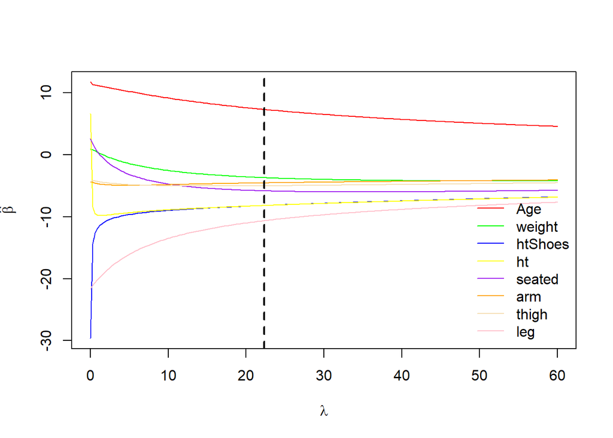

```r
lambda<- seq(0,60, length.out = 200)
rMod<- lm.ridge(hipcenter~. , data = seatpos, lambda= lambda)
#summary(rMod)

plot(lambda, 0 * lambda, type="n", xlab=expression(lambda), ylab=expression(hat(beta)), ylim=range(rMod$coef))

#assigning colors to the variables in the plot.
col<- c("red", "green", "blue", "yellow", "purple", "orange", "wheat", "pink")

for(j in 1:8) {
  lines(lambda, rMod$coef[j,], col=col[j])
}
legend("bottomright", legend = c("Age", "weight", "htShoes", "ht", "seated", "arm", "thigh", "leg"),col=col, lty=rep(1, by = 8), bty = "n")
abline(v=lambda[which.min(rMod$GCV)], lwd=2, lty = 2, col = "black" )
```

```r
pred<- coef(rMod)[which.min(rMod$GCV),-1]

#values from question 1
po = matrix ( c (64.800, 263.700, 181.080, 178.560, 91.440, 35.640, 40.950, 38.790 ) , nrow =1)

#prediction using values from question 1
pre<- 403.0148+ t(as.matrix(pred))%*%t(po)
```

Prediction using the information from question 11.1, give a prediction values of -194.5742785.

### Question 4 (Simulation question )

#### (A)

```r
x<- matrix(rnorm(10* 100, 0, 1), ncol = 10)

#subset matrix to first 3
x_<- x[,1:3]

e<- matrix(rnorm(100, 0, 1), nrow = 100)

y<-0 + 1*x[,1] + 2* x[,2] + 3* x[,3] + e

#fitting model to least square
tr<- summary(lm(y~x_))$sigma
```

#### (B)

```r
# This function takes the response y and the predictor matrix x and preform the subset and return the model sigma square with the lowest aic

sim<- function(x,y){

    #data frame to hold the response and predictors
    df<- data.frame(y, x)
    oo<- regsubsets(y~., data = df, nvmax = 10)
    oo.s<- summary(oo)

    #aic cacluation for the 11
    aic <- nrow(df)* log(oo.s$rss) + 2 * (2:11)

    #adding the the index to the coresssponding AIC
    temp<- matrix(nrow=10, ncol = 2)
    for( i in 1:length(aic)){
      temp[i,1]= aic[i]
      temp[i,2]= i

    }

    index<- temp[temp[,1]== min(temp[,1]), ]

    #identify the model with the lowest AIC then store model in temp2
    temp2<- (oo.s$which)[index[2],]

    #construct string with best model
    str = "lm(y~"

    co<- 0
    for(p in 1:length(temp2)){
      if(p > 1){
        k = p -1
        if(temp2[p]== TRUE){
          co = co + 1
          if(co == 1){
            str<- append(str, paste("X", k, sep =""))
          }else{
            str<- append(str, paste("+X", k, sep =""))
          }
        }
        if(p == length(temp2)){
            str<- append(str, paste(",data = df)", sep =""))
        }
      }
    }

    #concatination of model into one string
    t<- paste(str, collapse = " ")

    #return sigma from model with lowest AIC
    return((summary(eval(parse(text=t)))$sigma)^2)
}
#

aic_sig<- sim(x=x, y = y)
```

The aic $\sigma^2$ is 1.0185888 from the best model with the lowest AIC. While the true $\sigma^2$ is 1.0092516.

#### (C)

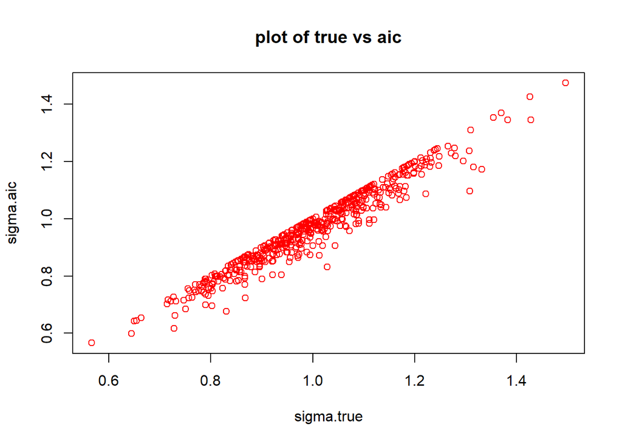

```r
sigma.true<- as.double(500)
sigma.aic<- as.double(500)

for(m in 1:500){
  # simulation of x
  x<- matrix(rnorm(10* 100, 0, 1), ncol = 10)
  #subset x to first 3 rows
  x_<- x[,1:3]
  #simulation of error
  e<- matrix(rnorm(100, 0, 1), nrow = 100)
  #simulation of y
  y<-0 + 1*x[,1] + 2* x[,2] + 3* x[,3] + e

  #storing true values
  sigma.true[m]<- (summary(lm(y~x_))$sigma)^2

  #storing aic
  sigma.aic[m]<- sim(x=x, y = y)


}

df<- data.frame(sigma.aic, sigma.true)
plot(sigma.true,sigma.aic, col = "red", main = "plot of true vs aic")
```

Most of the points are cluster between .8 and 1.3, points to aic $\sigma^2$ being biased.

#### (D)

```r
df<- data.frame(sigma.true, sigma.aic, sigma.true- sigma.aic)

#%percentage that contian the true sigma
prop<- length(df$sigma.true...sigma.aic[(df$sigma.true...sigma.aic== 0)])/ length(df)
```